# Hypnose Meditation - Traits by Behavior and Experience

# Datas

## Download

Datas from  
Bigdata.txt

```r
rm(list = ls())
# file.name <- "/Users/romain/Study/Prisca/Meditation_hypnose/Datas_raw/Bigdata.txt"
file.name <- "/Volumes/Backup_DD/From_BAIE/Prisca/Meditation_hypnose/Datas_raw/Bigdata.txt"
donne <- read.table(file.name, header = TRUE)
rm(file.name)

donne %>%
  mutate(genre = case_when(genre == 1 ~ "Homme",
                           genre == 0 ~ "Femme"),
         Medit_exp = case_when(Medit_exp == 0 ~ "Medit:0",
                               Medit_exp == 1 ~ "Medit:1"),
         Hypnos_exp = case_when(Hypnos_exp == 0 ~ "Hypn:0",
                                Hypnos_exp == 1 ~ "Hypn:1"),
         difficulty = X01_following_instructions + X02_difficulty + X03_distractedness,
         emotion    = X04_emotivity + X05_memories + X012_emotional_implication_in_sensations,
         absorp     = X011_intensity_of_sensation + X013_absorption_in_foods + X014_absorption_in_sensation,
         meta       = X016_observing_thoughts + X017_thoughts_as_interpretations_of_reality,
         realness   = X06_appetite + X07_mouthwatering + X08_realness_of_pictures + X09_appetite_increase +
                      X010_realness_of_sensation + X015_realness_of_sensations,
         states = case_when(Bloc == "2" & Version == "A" ~ "Meta_awareness",
                            Bloc == "3" & Version == "B" ~ "Meta_awareness",
                            Bloc == "2" & Version == "C" ~ "Meta_awareness",
                            Bloc == "3" & Version == "D" ~ "Meta_awareness",
                            Bloc == "3" & Version == "A" ~ "Absorption",
                            Bloc == "2" & Version == "B" ~ "Absorption",
                            Bloc == "3" & Version == "C" ~ "Absorption",
                            Bloc == "2" & Version == "D" ~ "Absorption",
                            Bloc == "1" & Version == "A" ~ "Controle",
                            Bloc == "1" & Version == "B" ~ "Controle",
                            Bloc == "1" & Version == "C" ~ "Controle",
                            Bloc == "1" & Version == "D" ~ "Controle"),
         Zoom = case_when(Zoom == "in" ~ "in",
                          Zoom == "out" ~ "out")) %>%
  dplyr::select(Sujet, age, genre, Bloc, Hypnos_exp, Medit_exp, states,
                Smoking, Canabis, Alcohol, Time_test, Timesincemeal,
                difficulty, emotion, absorp, meta, realness,
                Stabilo_20, Stabilo_40, Stabilo_1500, Stabilo_3000, Stabilo_mean, Stabilo_med, Stabilo_error,
                Zoom, RT, Valence_Theo, Valence_Suj, Label_Pict,
                Harvard_Obj_Total, FFMQ_Total, DES_mean, VVIQ_Total, MCQ_total, CFQ_Total) %>%
  mutate(genre = as.factor(genre),
         Medit_exp = as.factor(Medit_exp),
         Hypnos_exp = as.factor(Hypnos_exp),
         Smoking = as.factor(Smoking),
         Alcohol = as.factor(Alcohol),
         Canabis = as.factor(Canabis),
         Timesincemeal = as.numeric(as.character(Timesincemeal)),
         states = as.factor(states),
         Sujet = as.factor(Sujet),
         Bloc = as.factor(Bloc),
         Harvard_Obj_Total  = as.numeric(as.character(Harvard_Obj_Total)),
         FFMQ_Total = as.numeric(as.character(FFMQ_Total)),
         VVIQ_Total = as.numeric(as.character(VVIQ_Total)),
         DES_mean = as.numeric(as.character(DES_mean)),
         MCQ_total = as.numeric(as.character(MCQ_total)),
         CFQ_Total = as.numeric(as.character(CFQ_Total))) %>%
  data.frame() %>%
  unique() -> donne
```

Functions to select the pictures with best valence.

```r
select.best <- function(val, lab, n.x = 15) {
  # selectionne les pictures avec les 15 plus hautes valences
  #          et les pictures avec les 15 plus basses valences

  attraction <- vector(mode = "character", length(lab))

  x <- data.frame(Label = lab,
                  Valence = val) %>%
    group_by(Label) %>%
    summarise(Valence = unique(Valence))

  lab.neutre  <- x$Label[order(x$Valence, decreasing = FALSE)[1:n.x]]
  lab.attract <- x$Label[order(x$Valence, decreasing = TRUE)[1:n.x]]

  attraction[lab %in% lab.neutre]  <- "Neutre"
  attraction[lab %in% lab.attract] <- "Attract"
  return(attraction)
}
```

## FAB compute

Functions to compute FAB.  
$FAB = (RT^{Avoid}_{Attract} - RT^{Appro}_{Attract}) - (RT^{Avoid}_{Neutre} - RT^{Appro}_{Neutre})$

```r
#
# FAB <- function(RT, Zoom, Attraction){
#
#   x = data.frame(RT         = RT,
#                  Zoom       = Zoom,
#                  Attraction = Attraction)
#
#   Avoid.Attract <- x %>%
#     filter(Zoom == "out", Attraction == "Attract") %>%
#     dplyr::select(RT)
#   Avoid.Neutre <- x %>%
#     filter(Zoom == "out", Attraction == "Neutre") %>%
#     dplyr::select(RT)
#   Appro.Attract <- x %>%
#     filter(Zoom == "in", Attraction == "Attract") %>%
#     dplyr::select(RT)
#   Appro.Neutre <- x %>%
#     filter(Zoom == "in", Attraction == "Neutre") %>%
#     dplyr::select(RT)
#
#   FAB.score = (mean(Avoid.Attract$RT, na.rm = TRUE)-mean(Appro.Attract$RT, na.rm = TRUE))-(mean(Avoid.Neutre$RT, na.rm = TRUE) - mean(Appro.Neutre$RT, na.rm = TRUE))
#   return(FAB.score)
#
# }

FAB <- function(RT, Zoom, Attraction){

  x = data.frame(RT         = RT,
                 Zoom       = Zoom,
                 Attraction = Attraction)

  Avoid.Attract <- x %>%
    filter(Zoom == "out", Attraction == "Attract") %>%
    dplyr::select(RT)
  Avoid.Neutre <- x %>%
    filter(Zoom == "out", Attraction == "Neutre") %>%
    dplyr::select(RT)
  Appro.Attract <- x %>%
    filter(Zoom == "in", Attraction == "Attract") %>%
    dplyr::select(RT)
  Appro.Neutre <- x %>%
    filter(Zoom == "in", Attraction == "Neutre") %>%
    dplyr::select(RT)

  FAB.score = (mean(Avoid.Attract$RT, na.rm = TRUE)-mean(Appro.Attract$RT, na.rm = TRUE))-(mean(Avoid.Neutre$RT, na.rm = TRUE) - mean(Appro.Neutre$RT, na.rm = TRUE))


  return(list(FAB.score = FAB.score,
       Avoid.Attract = mean(Avoid.Attract$RT, na.rm = TRUE),
       Avoid.Neutre = mean(Avoid.Neutre$RT, na.rm = TRUE),
       Appro.Attract = mean(Appro.Attract$RT, na.rm = TRUE),
       Appro.Neutre = mean(Appro.Neutre$RT, na.rm = TRUE)))

}
```

```r
donne <- donne %>%
  group_by(Sujet) %>%
  mutate(Attraction = select.best(Valence_Suj, Label_Pict, 15)) %>%
  filter(Attraction != "") %>%
  group_by(Sujet, Bloc) %>%
  mutate(FAB           = FAB(RT, Zoom, Attraction)$FAB.score,
         Avoid.Attract = FAB(RT, Zoom, Attraction)$Avoid.Attract,
         Avoid.Neutre  = FAB(RT, Zoom, Attraction)$Avoid.Neutre,
         Appro.Attract = FAB(RT, Zoom, Attraction)$Appro.Attract,
         Appro.Neutre  = FAB(RT, Zoom, Attraction)$Appro.Neutre) %>%
  dplyr::select(-Smoking, -Canabis, -Alcohol, -Zoom, -RT, -Valence_Theo, -Valence_Suj, -Label_Pict, -Attraction)

# summary(donne)
```

## Delta compute

I compute the delta between states and Control condition. So :  
- Value_delta = Value_Meditation - Value_Control

```r
donne %>%
  dplyr::select(Sujet, Bloc, states,
                difficulty, emotion, absorp, meta, realness,
                FAB, Avoid.Attract, Avoid.Neutre, Appro.Attract, Appro.Neutre,
                Stabilo_20, Stabilo_40, Stabilo_1500, Stabilo_3000, Stabilo_error, Stabilo_mean, Stabilo_med) %>%
  unique() %>%
  filter(Bloc == 1) %>%
  data.frame() %>%
  dplyr::select(-Bloc, -states) %>%
  dplyr::rename(Ctrl_difficulty = difficulty,
                Ctrl_emotion = emotion,
                Ctrl_absorp = absorp,
                Ctrl_meta = meta,
                Ctrl_realness = realness,
                Ctrl_Stabilo_20    = Stabilo_20,
                Ctrl_Stabilo_40    = Stabilo_40,
                Ctrl_Stabilo_1500  = Stabilo_1500,
                Ctrl_Stabilo_3000  = Stabilo_3000,
                Ctrl_Stabilo_error = Stabilo_error,
                Ctrl_Stabilo_mean  = Stabilo_mean,
                Ctrl_Stabilo_med   = Stabilo_med,
                Ctrl_FAB           = FAB,
                Ctrl_Avoid.Attract = Avoid.Attract,
                Ctrl_Avoid.Neutre  = Avoid.Neutre,
                Ctrl_Appro.Attract = Appro.Attract,
                Ctrl_Appro.Neutre  = Appro.Neutre) -> donne.ctrl


donne %>%
  filter(Bloc != "1") %>%
  left_join(donne.ctrl) %>%
  group_by(Sujet, states) %>%
  mutate(difficulty_delta = difficulty - Ctrl_difficulty,
         emotion_delta = emotion - Ctrl_emotion,
         absorp_delta = absorp - Ctrl_absorp,
         meta_delta = meta - Ctrl_meta,
         realness_delta = realness - Ctrl_realness,
         Stabilo_20_delta   = Stabilo_20 - Ctrl_Stabilo_20,
         Stabilo_40_delta   = Stabilo_40 - Ctrl_Stabilo_40,
         Stabilo_1500_delta = Stabilo_1500 - Ctrl_Stabilo_1500,
         Stabilo_3000_delta = Stabilo_3000 - Ctrl_Stabilo_3000,
         Stabilo_error_delta= Stabilo_error - Ctrl_Stabilo_error,
         Stabilo_mean_delta = Stabilo_mean - Ctrl_Stabilo_mean,
         Stabilo_med_delta  = Stabilo_med - Ctrl_Stabilo_med,
         FAB_delta           = FAB - Ctrl_FAB,
         Avoid.Attract_delta = Avoid.Attract - Ctrl_Avoid.Attract,
         Avoid.Neutre_delta  = Avoid.Neutre - Ctrl_Avoid.Neutre,
         Appro.Attract_delta = Appro.Attract - Ctrl_Appro.Attract,
         Appro.Neutre_delta  = Appro.Neutre - Ctrl_Appro.Neutre) %>%
  dplyr::select(Sujet, Bloc, age, genre, Hypnos_exp, Medit_exp, states,
                difficulty_delta, emotion_delta, absorp_delta, meta_delta, realness_delta,
                FFMQ_Total, Harvard_Obj_Total,
                FAB_delta, Avoid.Attract_delta, Avoid.Neutre_delta, Appro.Attract_delta, Appro.Neutre_delta,
                Stabilo_20_delta, Stabilo_40_delta, Stabilo_1500_delta, Stabilo_3000_delta,
                Stabilo_error_delta, Stabilo_mean_delta, Stabilo_med_delta) %>%
  unique() -> donne.delta

rm(donne.ctrl)
```

## Normalisation des données FFMQ and Harvard

```r
m.f <- max(donne$FFMQ_Total, na.rm = TRUE)
m.h <- max(donne$Harvard_Obj_Total, na.rm = TRUE)

donne.delta %>%
  mutate(FFMQ_Total = FFMQ_Total/m.f,
         Harvard_Obj_Total = Harvard_Obj_Total/m.h) %>%
  unique() -> donne.use

#summary(donne.use)
```

## Phéno

```r
#file.name <- "/Users/romain/Study/Prisca/Meditation_hypnose/Datas_raw/PhenoSummary.xlsx"
file.name <- "/Volumes/Backup_DD/From_BAIE/Prisca/Meditation_hypnose/Datas_raw/PhenoSummary.xlsx"

datas.pheno <- datas.base <- read_xlsx(file.name, sheet = 1, skip = 3) %>%
  dplyr::select(`Code Sujet`, C...4, H...5, M...6, C...7, H...8, M...9, C...15, H...16, M...17) %>%
  rename("Sujet" = `Code Sujet`,
         "Lauranne_C_8cat" =  C...4,
         "Lauranne_H_8cat" =  H...5,
         "Lauranne_M_8cat" =  M...6,
         "Aurelie_C_8cat" =  C...7,
         "Aurelie_H_8cat" =  H...8,
         "Aurelie_M_8cat" =  M...9,
         "C_11cat" =  C...15,
         "H_11cat" =  H...16,
         "M_11cat" =  M...17) %>%
  mutate(Sujet = as.factor(Sujet),
         Lauranne_C_8cat = as.numeric(as.character(Lauranne_C_8cat)),
         Lauranne_H_8cat = as.numeric(as.character(Lauranne_H_8cat)),
         Lauranne_M_8cat = as.numeric(as.character(Lauranne_M_8cat)),
         C_11cat = as.numeric(as.character(C_11cat)),
         H_11cat = as.numeric(as.character(H_11cat)),
         M_11cat = as.numeric(as.character(M_11cat))) %>%
  drop_na(Sujet)

rm(file.name)


datas.pheno %>%
  dplyr::select(Sujet, Lauranne_C_8cat, Lauranne_H_8cat, Lauranne_M_8cat,
                Aurelie_C_8cat, Aurelie_H_8cat, Aurelie_M_8cat) %>%
  gather(key = "states",
         value = "Pheno_Etat", -Sujet) %>%
  mutate(states = case_when(states == "Lauranne_C_8cat" ~ "Controle",
                            states == "Lauranne_M_8cat" ~ "Meta_awareness",
                            states == "Lauranne_H_8cat" ~ "Absorption",
                            states == "Aurelie_C_8cat" ~ "Controle",
                            states == "Aurelie_M_8cat" ~ "Meta_awareness",
                            states == "Aurelie_H_8cat" ~ "Absorption")) %>%
  group_by(Sujet, states) %>%
  summarise(Pheno_Etat = mean(Pheno_Etat, na.rm = TRUE)) %>%
  mutate(states = as.factor(states)) %>%
  data.frame() -> datas.pheno.Pheno_Etat

datas.pheno.Pheno_Etat %>%
  filter(states == "Controle") %>%
  dplyr::select(-states) %>%
  rename("Pheno_Etat_Ctrl" = Pheno_Etat) %>%
  data.frame() -> datas.pheno.Pheno_Etat.Crtl

datas.pheno.Pheno_Etat %>%
  filter(states != "Controle") %>%
  left_join(datas.pheno.Pheno_Etat.Crtl) %>%
  group_by(Sujet, states) %>%
  summarise(Pheno_Etat_delta = Pheno_Etat - Pheno_Etat_Ctrl) %>%
  mutate(states = as.factor(states)) %>%
  data.frame() -> datas.pheno.Pheno_Etat


datas.pheno %>%
  dplyr::select(Sujet, C_11cat, H_11cat, M_11cat) %>%
  gather(key = "states",
         value = "Pheno_Image", -Sujet) %>%
  mutate(states = case_when(states == "C_11cat" ~ "Controle",
                            states == "M_11cat" ~ "Meta_awareness",
                            states == "H_11cat" ~ "Absorption")) %>%
  group_by(Sujet, states) %>%
  summarise(Pheno_Image = mean(Pheno_Image, na.rm = TRUE)) %>%
  mutate(states = as.factor(states)) %>%
  data.frame() -> datas.pheno.Pheno_Image

datas.pheno.Pheno_Image %>%
  filter(states == "Controle") %>%
  dplyr::select(-states) %>%
  rename("Pheno_Image_Ctrl" = Pheno_Image) %>%
  data.frame() -> datas.pheno.Pheno_Image.Crtl

datas.pheno.Pheno_Image %>%
  filter(states != "Controle") %>%
  left_join(datas.pheno.Pheno_Image.Crtl) %>%
  group_by(Sujet, states) %>%
  summarise(Pheno_Image_delta = Pheno_Image - Pheno_Image_Ctrl) %>%
  mutate(states = as.factor(states)) %>%
  data.frame() -> datas.pheno.Pheno_Image

# Fusion des deux pheno
datas.pheno.Pheno_Etat %>%
  left_join(datas.pheno.Pheno_Image) %>%
  mutate(states = as.factor(states)) %>%
  data.frame() -> datas.pheno

rm(datas.pheno.Pheno_Etat, datas.pheno.Pheno_Image,
   datas.pheno.Pheno_Etat.Ctrl, datas.pheno.Pheno_Image.Ctrl)

# summary(datas.pheno)

# Fusion avec tout le jeux de données
donne.use %>%
  left_join(datas.pheno) -> donne.use

# summary(donne.use)
```

# Stat

## Functions definition

```r
Analysis.AL <- function(var.interest, datas){

  # var.interest <- "difficulty_delta"
  # datas <- donne.use

  eval(parse(text = paste("datas <- mutate(datas, col.interest = ", var.interest, ")", sep = "")))

  datas %>%
    data.frame() %>%
    dplyr::select(Bloc, states, col.interest) %>%
    unique() %>%
    ggplot(aes(x = Bloc, y = col.interest, fill = states)) +
    geom_boxplot(alpha = 0.95) +
    scale_fill_grey() +
    theme_classic() +
    theme(legend.direction = "vertical",
          legend.box = "horizontal",
          legend.justification = c(0, 1),
          axis.title.x = element_blank(),
          axis.title.y = element_text(size = 12, face = "bold"),
          axis.text.x = element_text(face = "bold", size = 12, angle = 0, hjust = 1),
          axis.text.y = element_text(face = "bold", size = 10, angle = 0, hjust = 1)) +
    labs(fill = "States",
         y = var.interest,
         x = "Bloc") -> p1



  datas %>%
    data.frame() %>%
    dplyr::select(Bloc, states, col.interest) %>%
    unique() %>%
    ggplot(aes(x = col.interest, fill = states)) +
    geom_density(alpha = 0.6) +
    scale_fill_grey() +
    theme_classic() +
    theme(legend.direction = "vertical",
          legend.box = "horizontal",
          legend.justification = c(0, 1),
          axis.title.x = element_blank(),
          axis.title.y = element_text(size = 12, face = "bold"),
          axis.text.x = element_text(face = "bold", size = 12, angle = 0, hjust = 1),
          axis.text.y = element_text(face = "bold", size = 10, angle = 0, hjust = 1))

  model <- lm(col.interest ~ states*Bloc, data = datas)
  anova(model) -> anova.res


  sjPlot::plot_model(model,
             type = "eff",
             terms = c("Bloc", "states")) +
    ggtitle("Predicted Values") -> p2

  emm <- emmeans(model, ~ states*Bloc,
                    type = "response")

  test(emm, adjust = "FDR") -> emerg.test

  des_cont <- list("Abso_3 VS Abso_2" = c(-1, 0, 1, 0),
                   "Meta_3 VS Meta_2" = c(0, -1, 0, 1),
                   "Abso_2 VS Meta_2" = c(1, -1, 0, 0),
                   "Abso_3 VS Meta_3" = c(0, 0, -1, 1))

  contrast(emm, des_cont, adjust = "FDR") -> post.hoc

  output = list(p1 = p1,
                p2 = p2,
                emerg.test = emerg.test,
                anova.res = anova.res,
                post.hoc = post.hoc)

}
```

## Run analysis

L’idée était de faire des tests très simplistes pour voir le comportement de toutes les variables étudiées (FAB, Blast et Likert) en fonction de seulement deux paramètres:

- **Bloc**, avec 2 niveaux (2 & 3)
- **States**, avec 2 niveaux (meta-awarness & Absorption)
- et leur interaction

Comme notre design n’est pas du tout équilibré, nous utilisons seulement le bloc 2 et 3. Et les mesures sont la différence avec la condition Contrôle (delta).

Pour chaque mesure, nous trouverons:

- ANOVA resuts:  
  Comme son nom l’indique, l’analyse de variance pour voir les effets des 2 facteurs (Bloc et states) et de l’interaction **Bloc*States**.
- EMERGENCE results:  
  Ce sont les tests d’émergence pour tous les blocs et toutes les conditions. Ca nous permet donc de voir si la mesure faite est différente de la condition Contrôle.
- POST-HOC results:  
  Ce sont des contrastes. Entre différents blocs pour un même état. Et aussi entre différents états dans un même bloc.
- Deux figures:  
  La première montre les données brutes et la seconde montre les effets estimés (pour mieux comprendre les tests).

```
##
##
##  difficulty_delta
##
##
## ANOVA results
##              Df     Sum Sq    Mean Sq    F value       Pr(>F)
## states        1  345.84500  345.84500  9.8788954 1.931478e-03
## Bloc          1   30.22963   30.22963  0.8634948 3.539056e-01
## states:Bloc   1 2578.22051 2578.22051 73.6456235 2.849510e-15
## Residuals   196 6861.65986   35.00847         NA           NA
##
##
## EMERGENCE results
##           states Bloc    emmean      p.value
## 1     Absorption    2  4.980392 3.536853e-08
## 2 Meta_awareness    2 -4.816327 8.786689e-08
## 3     Absorption    3 -2.979592 7.026722e-04
## 4 Meta_awareness    3  1.588235 5.669719e-02
##
##
## POST-HOC results
##           contrast  estimate      p.value
## 1 Abso_3 VS Abso_2 -7.959984 3.747554e-10
## 2 Meta_3 VS Meta_2  6.404562 2.420566e-07
## 3 Abso_2 VS Meta_2  9.796719 7.697591e-14
## 4 Abso_3 VS Meta_3  4.567827 1.543064e-04
```

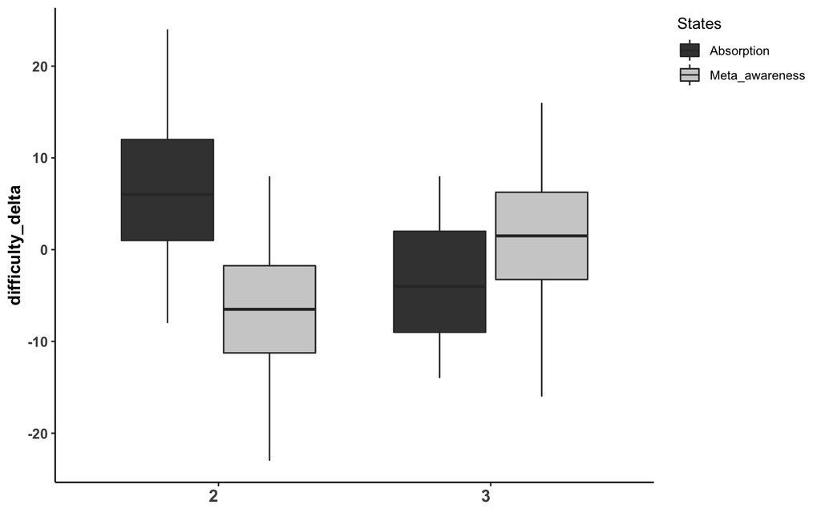

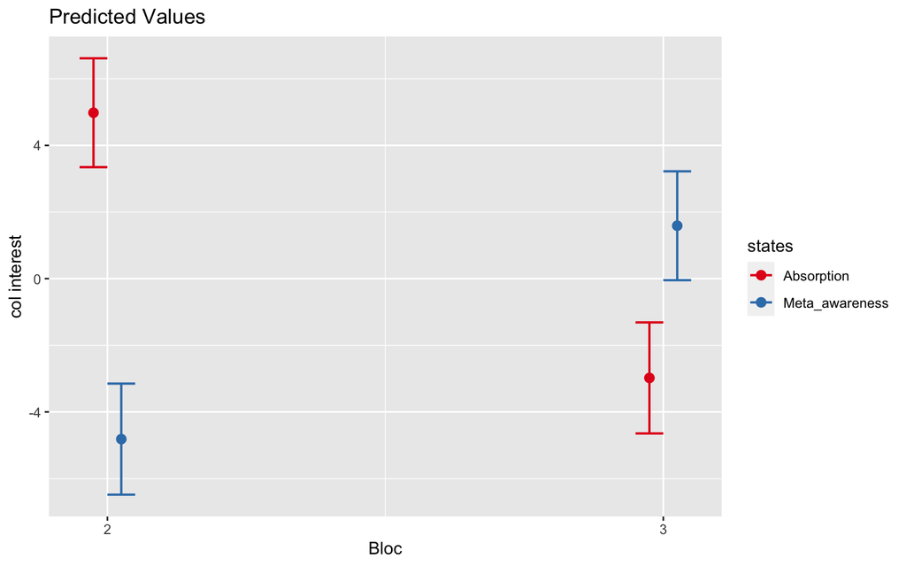

```
##
##
##  emotion_delta
##
##
## ANOVA results
##              Df      Sum Sq   Mean Sq   F value    Pr(>F)
## states        1   30.420000 30.420000 1.9305309 0.1662767
## Bloc          1    2.325098  2.325098 0.1475567 0.7012977
## states:Bloc   1   17.839528 17.839528 1.1321420 0.2886280
## Residuals   196 3088.435374 15.757323        NA        NA
##
##
## EMERGENCE results
##           states Bloc      emmean   p.value
## 1     Absorption    2  0.64705882 0.4916028
## 2 Meta_awareness    2 -0.73469388 0.4916028
## 3     Absorption    3  0.26530612 0.8538848
## 4 Meta_awareness    3  0.07843137 0.8879341
##
##
## POST-HOC results
##           contrast   estimate   p.value
## 1 Abso_3 VS Abso_2 -0.3817527 0.8141919
## 2 Meta_3 VS Meta_2  0.8131253 0.6141962
## 3 Abso_2 VS Meta_2  1.3817527 0.3336498
## 4 Abso_3 VS Meta_3 -0.1868747 0.8141919
```

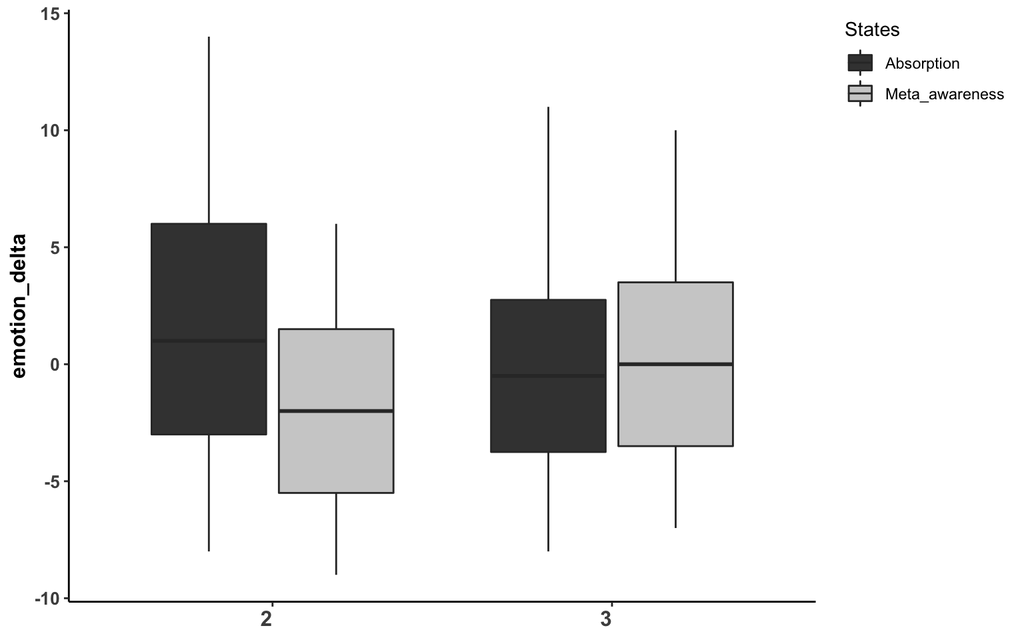

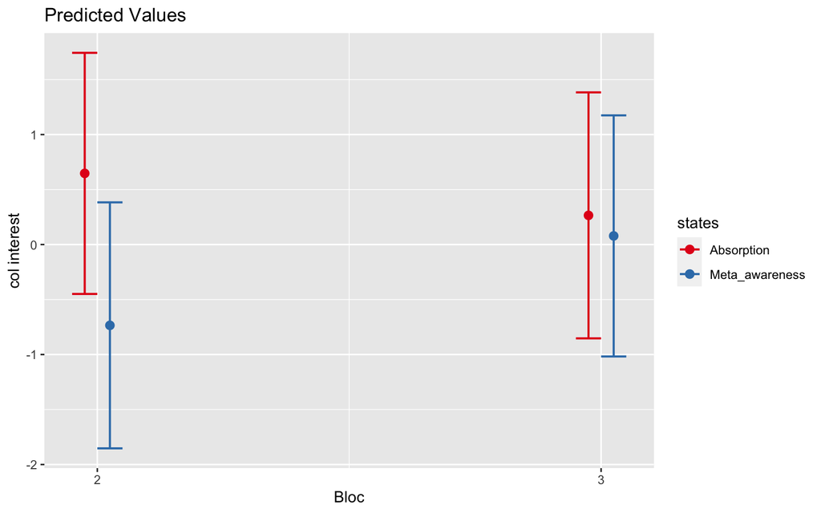

```
##
##
##  absorp_delta
##
##
## ANOVA results
##              Df       Sum Sq      Mean Sq      F value    Pr(>F)
## states        1 6.125000e+00 6.1250000000 7.893268e-01 0.3753928
## Bloc          1 2.953631e+00 2.9536314526 3.806335e-01 0.5379804
## states:Bloc   1 2.000800e-06 0.0000020008 2.578425e-07 0.9995954
## Residuals   196 1.520916e+03 7.7597773803           NA        NA
##
##
## EMERGENCE results
##           states Bloc      emmean   p.value
## 1     Absorption    2  0.03921569 0.9200218
## 2 Meta_awareness    2 -0.30612245 0.8115260
## 3     Absorption    3 -0.20408163 0.8115260
## 4 Meta_awareness    3 -0.54901961 0.6434527
##
##
## POST-HOC results
##           contrast   estimate   p.value
## 1 Abso_3 VS Abso_2 -0.2432973 0.6633933
## 2 Meta_3 VS Meta_2 -0.2428972 0.6633933
## 3 Abso_2 VS Meta_2  0.3453381 0.6633933
## 4 Abso_3 VS Meta_3 -0.3449380 0.6633933
```

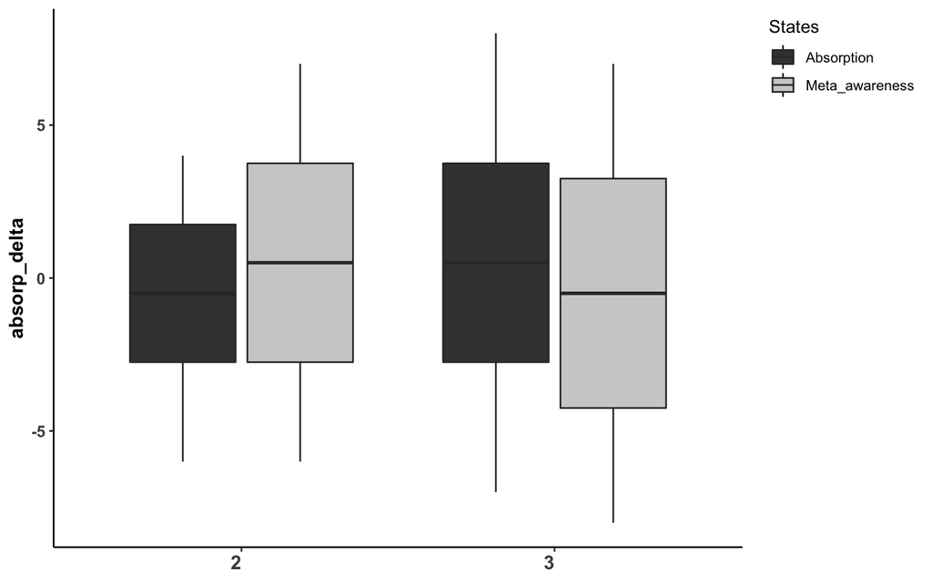

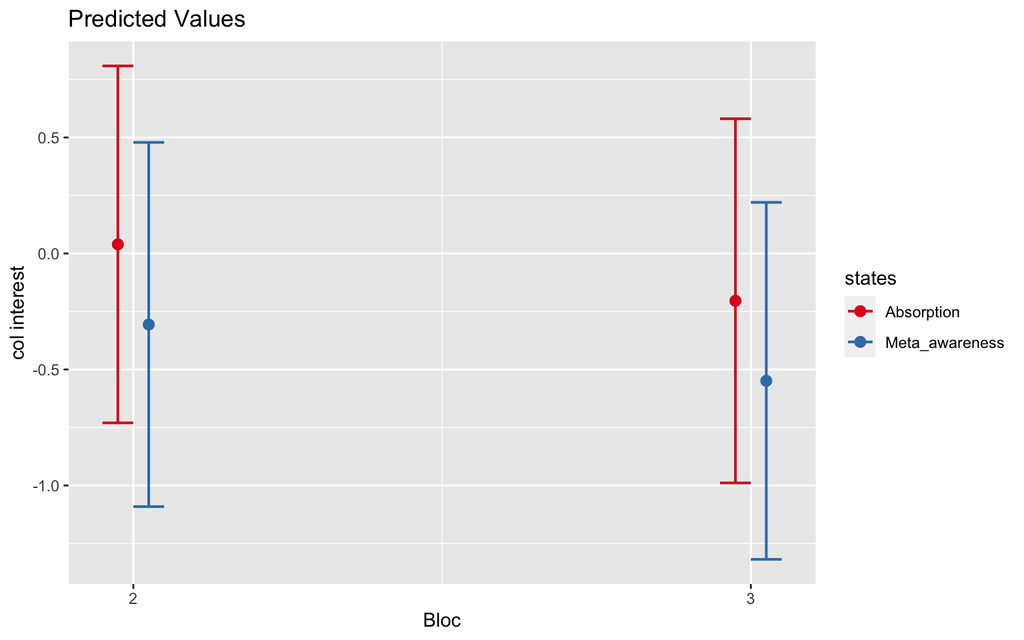

```
##
##
##  meta_delta
##
##
## ANOVA results
##              Df      Sum Sq   Mean Sq   F value    Pr(>F)
## states        1    0.500000  0.500000 0.0838994 0.7723872
## Bloc          1    5.186275  5.186275 0.8702506 0.3520337
## states:Bloc   1   10.328099 10.328099 1.7330426 0.1895601
## Residuals   196 1168.065626  5.959519        NA        NA
##
##
## EMERGENCE results
##           states Bloc     emmean   p.value
## 1     Absorption    2 -0.2549020 0.6090052
## 2 Meta_awareness    2  0.3061224 0.6090052
## 3     Absorption    3 -0.1224490 0.7258803
## 4 Meta_awareness    3 -0.4705882 0.6090052
##
##
## POST-HOC results
##           contrast   estimate   p.value
## 1 Abso_3 VS Abso_2  0.1324530 0.7864988
## 2 Meta_3 VS Meta_2 -0.7767107 0.4533247
## 3 Abso_2 VS Meta_2 -0.5610244 0.5040446
## 4 Abso_3 VS Meta_3 -0.3481393 0.6356714
```

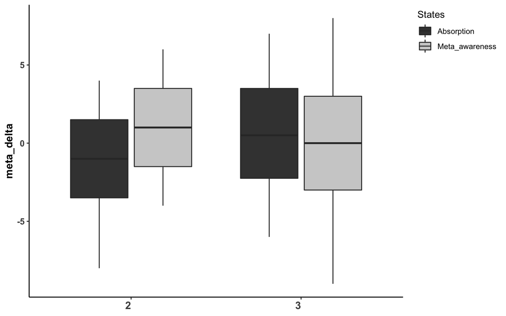

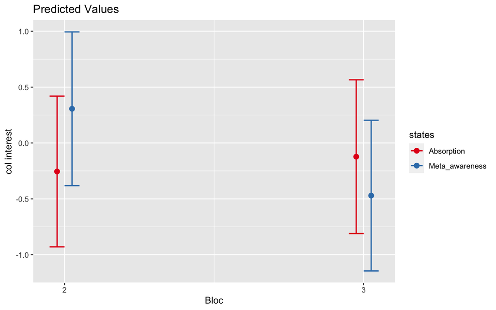

```
##
##
##  realness_delta
##
##
## ANOVA results
##              Df      Sum Sq    Mean Sq    F value       Pr(>F)
## states        1   292.82000  292.82000  3.2049876 7.495758e-02
## Bloc          1    21.02954   21.02954  0.2301735 6.319301e-01
## states:Bloc   1  2069.61633 2069.61633 22.6524647 3.762508e-06
## Residuals   196 17907.31413   91.36385         NA           NA
##
##
## EMERGENCE results
##           states Bloc    emmean      p.value
## 1     Absorption    2  3.235294 0.0331127010
## 2 Meta_awareness    2 -5.632653 0.0002190264
## 3     Absorption    3 -2.551020 0.0843009045
## 4 Meta_awareness    3  1.450980 0.2796631325
##
##
## POST-HOC results
##           contrast  estimate      p.value
## 1 Abso_3 VS Abso_2 -5.786315 3.745085e-03
## 2 Meta_3 VS Meta_2  7.083633 5.504447e-04
## 3 Abso_2 VS Meta_2  8.867947 2.569146e-05
## 4 Abso_3 VS Meta_3  4.002001 3.763438e-02
```

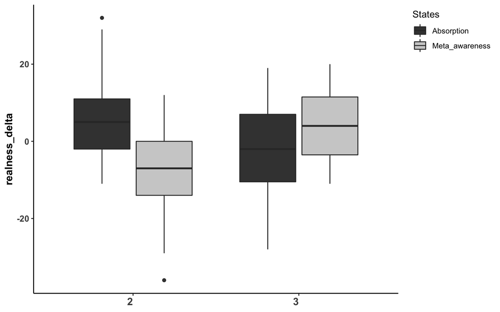

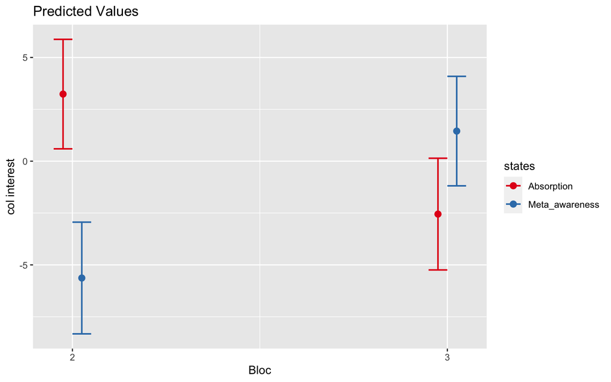

```
##
##
##  Stabilo_20_delta
##
##
## ANOVA results
##              Df     Sum Sq   Mean Sq    F value      Pr(>F)
## states        1   11.13302  11.13302 0.23782648 0.626325416
## Bloc          1  436.54700 436.54700 9.32563278 0.002573693
## states:Bloc   1    1.99410   1.99410 0.04259849 0.836697386
## Residuals   196 9175.05694  46.81151         NA          NA
##
##
## EMERGENCE results
##           states Bloc     emmean     p.value
## 1     Absorption    2 -0.3523290 0.713453648
## 2 Meta_awareness    2  0.3783929 0.713453648
## 3     Absorption    3 -3.1079918 0.006852520
## 4 Meta_awareness    3 -2.7767594 0.008357909
##
##
## POST-HOC results
##           contrast   estimate    p.value
## 1 Abso_3 VS Abso_2 -2.7556628 0.09087788
## 2 Meta_3 VS Meta_2 -3.1551523 0.08878690
## 3 Abso_2 VS Meta_2 -0.7307219 0.79202212
## 4 Abso_3 VS Meta_3  0.3312324 0.80902272
```

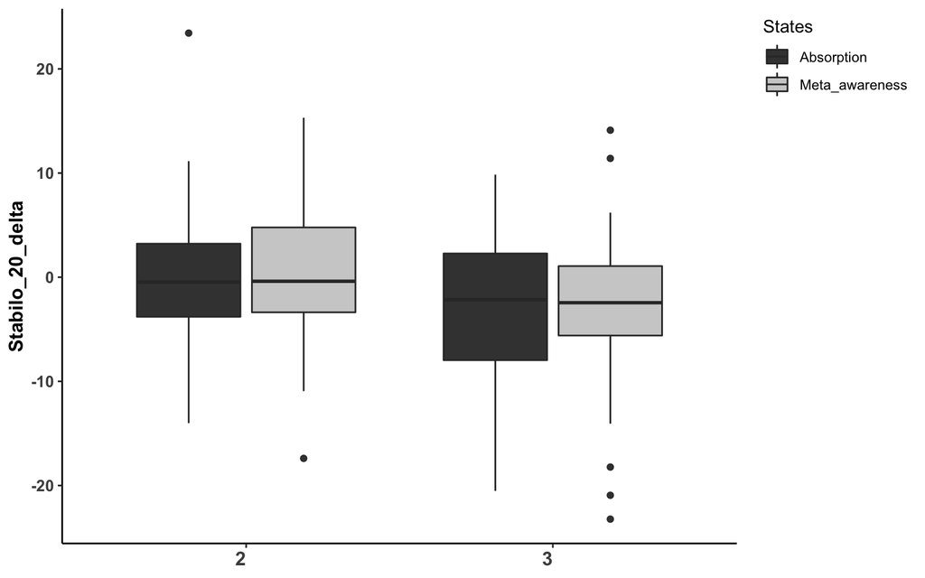

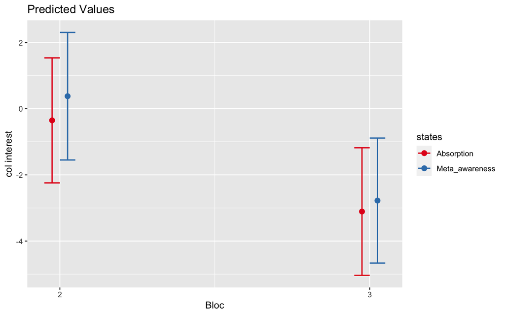

```
##
##
##  Stabilo_40_delta
##
##
## ANOVA results
##              Df     Sum Sq   Mean Sq    F value       Pr(>F)
## states        1   121.7437  121.7437  0.9095252 0.3414151183
## Bloc          1  1983.2993 1983.2993 14.8168759 0.0001602845
## states:Bloc   1   267.8412  267.8412  2.0009940 0.1587827237
## Residuals   196 26235.4003  133.8541         NA           NA
##
##
## EMERGENCE results
##           states Bloc     emmean      p.value
## 1     Absorption    2 -3.1387804 7.217025e-02
## 2 Meta_awareness    2  0.8625592 6.023428e-01
## 3     Absorption    3 -7.1231898 5.169040e-05
## 4 Meta_awareness    3 -7.7517392 1.344281e-05
##
##
## POST-HOC results
##           contrast   estimate     p.value
## 1 Abso_3 VS Abso_2 -3.9844094 0.115627293
## 2 Meta_3 VS Meta_2 -8.6142984 0.001032392
## 3 Abso_2 VS Meta_2 -4.0013396 0.115627293
## 4 Abso_3 VS Meta_3 -0.6285494 0.786226512
```

[18 more figures not shown]

```r
var.to.analys <- c("difficulty_delta", "emotion_delta", "absorp_delta", "meta_delta", "realness_delta", "Stabilo_20_delta", "Stabilo_40_delta", "Stabilo_1500_delta", "Stabilo_3000_delta", "Stabilo_mean_delta", "Stabilo_med_delta", "Stabilo_error_delta", "FAB_delta", "Pheno_Etat_delta", "Pheno_Image_delta")


lapply(var.to.analys, Analysis.AL, datas  = donne.use) -> output


for (xi in 1:length(var.to.analys)){
  cat('\n\n', var.to.analys[xi], '\n')

  # output <- Analysis.AL(donne.use, xi)
  cat('\n\nANOVA results\n')
  print(as.data.frame(output[[xi]]$anova.res))

  cat('\n\nEMERGENCE results\n')
  print(as.data.frame(dplyr::select(output[[xi]]$emerg.test, -SE, -df, -t.ratio)))
  cat('\n\nPOST-HOC results\n')
  print(as.data.frame(dplyr::select(as.data.frame(output[[xi]]$post.hoc), -SE, -df, -t.ratio)))

  suppressWarnings(print(output[[xi]]$p1))
  cat('\n')
  suppressWarnings(print(output[[xi]]$p2))

  }
```